# Introduction to Cultural Data Science: Assignment 2

Akaran Sivakumar

2024-11-12

# Part 1

## Loading in data and packages

Load the ‘divorce_margarine’ dataset from the ‘dslabs’ package. Investigate the correlation between margarine consumption and divorce rates in Maine. Would an increase in the preference for margarine lead to skyrocketing divorce rates?

```r
# install.packages('dslabs') # for data
# Importing necessary libraries
library(dslabs)
library(tidyverse)
# Loading the dataset
# Assigning the divorce_margarine dataset to a dataframe called df
df <- dslabs::divorce_margarine

# Checking the structure of the dataset to understand its contents
str(df)
```

```
## 'data.frame':    10 obs. of  3 variables:
##  $ divorce_rate_maine              : num  5 4.7 4.6 4.4 4.3 4.1 4.2 4.2 4.2 4.1
##  $ margarine_consumption_per_capita: num  8.2 7 6.5 5.3 5.2 4 4.6 4.5 4.2 3.7
##  $ year                            : int  2000 2001 2002 2003 2004 2005 2006 2007 2008 2009
```

## Inspection of data

```r
# Viewing the 'divorce_rate_maine' column in the dataframe
df$divorce_rate_maine
```

```
##  [1] 5.0 4.7 4.6 4.4 4.3 4.1 4.2 4.2 4.2 4.1
```

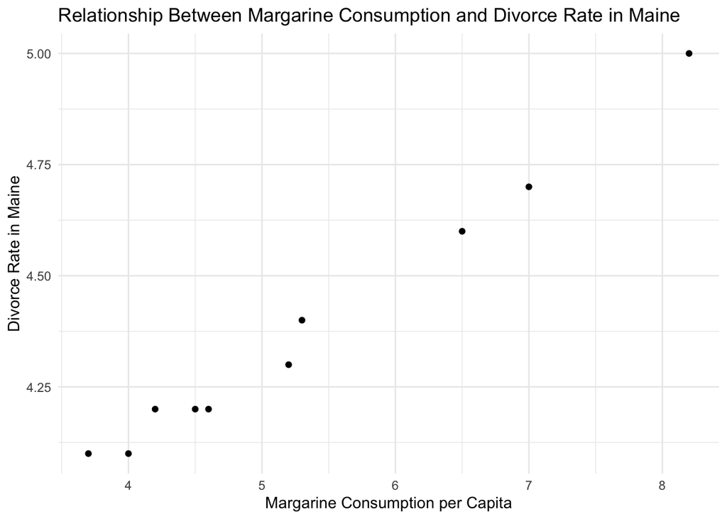

```r
# Plotting the relationship between margarine consumption per capita and divorce rate in Maine
ggplot(data = df,
       aes(x = margarine_consumption_per_capita,
           y = divorce_rate_maine)) +
  geom_point() +  # Scatter plot to show data points
  labs(
    title = "Relationship Between Margarine Consumption and Divorce Rate in Maine",
    x = "Margarine Consumption per Capita",
    y = "Divorce Rate in Maine"
  ) +
  theme_minimal()  # Minimal theme for a cleaner look
```

## Correlation Test

```r
# Conducting a correlation test between divorce rate in Maine and margarine consumption per capita
cor.test(x = df$divorce_rate_maine, y = df$margarine_consumption_per_capita)
```

```
##
##  Pearson's product-moment correlation
##
## data:  df$divorce_rate_maine and df$margarine_consumption_per_capita
## t = 23.055, df = 8, p-value = 1.33e-08
## alternative hypothesis: true correlation is not equal to 0
## 95 percent confidence interval:
##  0.9676666 0.9983038
## sample estimates:
##       cor
## 0.9925585
```

## Relationship plotting

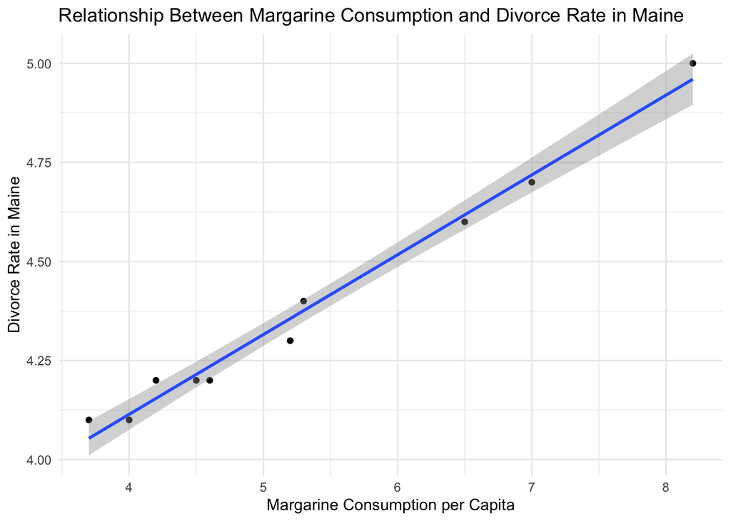

```r
# Plotting the relationship between margarine consumption per capita and divorce rate in Maine
ggplot(data = df,
       aes(x = margarine_consumption_per_capita,
           y = divorce_rate_maine)) +
  geom_point() +  # Scatter plot for data points
  geom_smooth(method = "lm", se = TRUE) +  # Adding a linear regression line with confidence interval
  ggtitle("Relationship Between Margarine Consumption and Divorce Rate in Maine") +  # Descriptive title
  xlab("Margarine Consumption per Capita") +  # Label for x-axis
  ylab("Divorce Rate in Maine") +  # Label for y-axis
  theme_minimal()  # Minimal theme for cleaner appearance
```

**Answer: Even though these two variables are strongly correlated, they are not causally linked. Correlation means that two things tend to happen together, but it does not imply that one causes the other. In this case, the relationship is likely coincidental or due to other underlying factors, not because one variable affects the other. So, no, an increase in the preference for margarine will not lead to an increase in divorce rates.**

# Part 2

## Loading in data

Load the ‘GSSvocab’ dataset from the ‘car’ package. This dataset contains people’s scores on an English vocabulary test and includes demographic information.

```r
# Load the 'car' package
library(car)
# Loading the GSSvocab dataset
data("GSSvocab")  # Loads the dataset into the environment

# Assigning the GSSvocab dataset to the variable 'data'
data <- GSSvocab
```

## Preprocessing

Filter for the year 1978 and remove rows with missing values (the function na.exclude() is one way to do this – check out the documentation!).

```r
# Filtering the dataset to include only rows where the year is 1978
filt_data <- filter(data, year == "1978")

# Removing any rows with missing (NA) values from the filtered dataset
filt_data <- na.omit(filt_data)
```

## Education level and Score on vocabulary test

Is a person’s score on the vocabulary test (‘vocab’) significantly impacted by their level of education (‘educ’)? Visualize the relationship in a plot and build a model. Briefly explain the results.

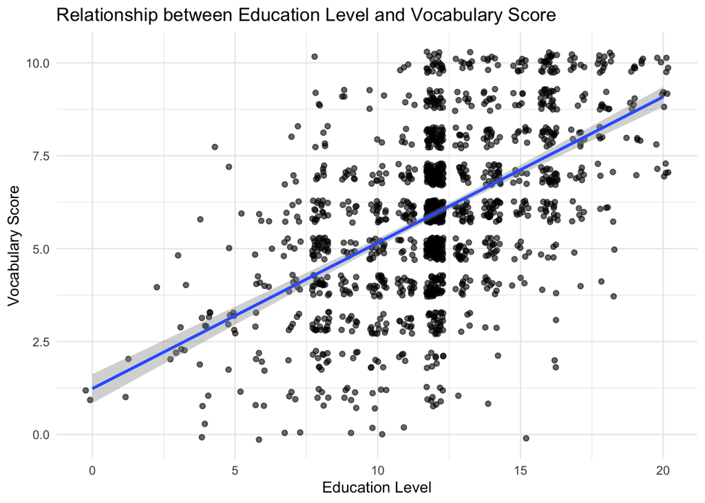

```r
# Plotting the relationship between education level and vocabulary score for the filtered dataset
ggplot(filt_data, aes(x = educ, y = vocab)) +
  geom_jitter(width = 0.3, height = 0.3, alpha = 0.6) +  # Adds jittered points for better visibility of overlapping points
  geom_smooth(method = "lm", se = TRUE) +  # Adds a linear regression line with confidence interval shading
  labs(
    title = "Relationship between Education Level and Vocabulary Score",
    x = "Education Level",
    y = "Vocabulary Score"
  ) +
  theme_minimal()  # Minimal theme for a clean look
```

```r
# Step 2: Building a linear model to assess the relationship between education level and vocabulary score
model <- lm(vocab ~ educ, data = data)  # Linear regression with 'vocab' as the dependent variable and 'educ' as the predictor

# Step 3: Summarize the model to check the significance
summary(model)
```

```
##
## Call:
## lm(formula = vocab ~ educ, data = data)
##
## Residuals:
##     Min      1Q  Median      3Q     Max
## -8.2853 -1.2775  0.0526  1.3846  8.3944
##
## Coefficients:
##             Estimate Std. Error t value Pr(>|t|)
## (Intercept) 1.605635   0.050003   32.11   <2e-16 ***
## educ        0.333982   0.003705   90.15   <2e-16 ***
## ---
## Signif. codes:  0 '***' 0.001 '**' 0.01 '*' 0.05 '.' 0.1 ' ' 1
##
## Residual standard error: 1.849 on 27471 degrees of freedom
##   (1394 observations deleted due to missingness)
## Multiple R-squared:  0.2283, Adjusted R-squared:  0.2283
## F-statistic:  8128 on 1 and 27471 DF,  p-value: < 2.2e-16
```

**Answer: The model suggests a statistically significant positive relationship between education level and vocabulary score, with each additional year of education increasing vocabulary score by approximately 0.33 points. The model explains about 22.83% of the variability in vocabulary scores, indicating that while education has a meaningful impact, other factors also contribute to vocabulary knowledge.**

## The impact of being Native-Born

Whether a person is the native of an English-speaking country (‘nativeBorn’) could potentially have an impact on the size of their vocabulary. Visualize the relationship and add the predictor to the model. Briefly explain the results.

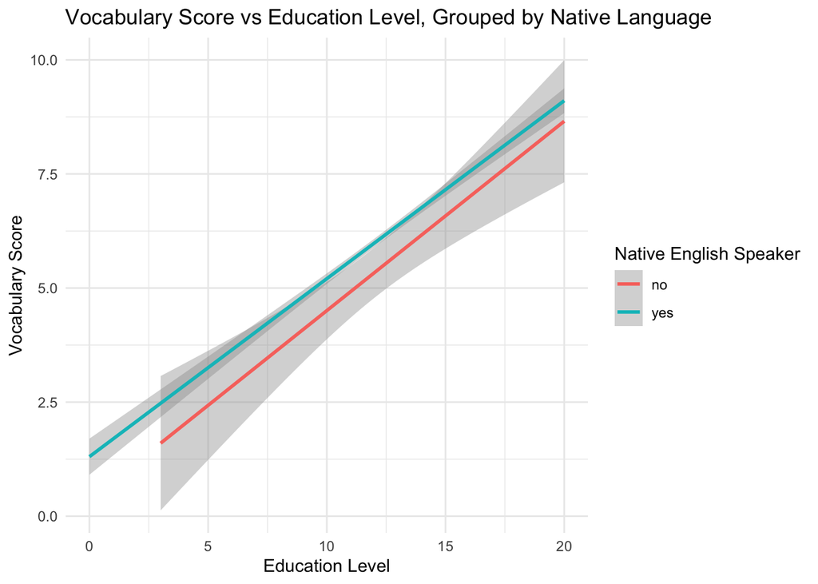

```r
# Filtering out rows with missing values in `filt_data` to create a cleaned dataset
data_clean <- na.omit(filt_data)

# Plotting the relationship between education level and vocabulary score, grouped by native language status
ggplot(data_clean, aes(x = educ, y = vocab, color = factor(nativeBorn))) +
  # geom_point(alpha = 0.5) +  # Optionally add points with transparency
  geom_smooth(method = "lm") +  # Adds a linear regression line for each group
  labs(
    title = "Vocabulary Score vs Education Level, Grouped by Native Language",
    x = "Education Level",
    y = "Vocabulary Score",
    color = "Native English Speaker"  # Label for the legend
  ) +
  theme_minimal()  # Minimal theme for a clean, modern look
```

```r
# Counting the number of native and non-native born individuals
# This provides an idea of the data balance between the groups
data_clean %>%
  count(nativeBorn)
```

```
##   nativeBorn    n
## 1         no   89
## 2        yes 1388
```

[figure not shown]

```r
# Plotting histograms of vocabulary scores, faceted by native language status
ggplot(data_clean, aes(x = vocab)) +
  geom_histogram(binwidth = 1, fill = "skyblue", color = "black", alpha = 0.7) +  # Histogram with customized binwidth
  facet_wrap(~ nativeBorn, labeller = as_labeller(c("0" = "Non-Native", "1" = "Native"))) +  # Facet by native status with labels
  labs(
    title = "Distribution of Vocabulary Scores by Native Status",
    x = "Vocabulary Score",
    y = "Count"
  ) +
  theme_minimal()
```

```r
# Step 2: Updating the linear model to include `nativeBorn` as an additional predictor
# This tests if native language status has a significant effect on vocabulary score
model2 <- lm(vocab ~ educ + nativeBorn, data = data_clean)

# Step 3: Summarizing the updated model to review the effect of `nativeBorn` and `educ` on `vocab`
summary(model2)
```

```
##
## Call:
## lm(formula = vocab ~ educ + nativeBorn, data = data_clean)
##
## Residuals:
##    Min     1Q Median     3Q    Max
## -7.162 -1.200  0.015  1.231  5.803
##
## Coefficients:
##               Estimate Std. Error t value Pr(>|t|)
## (Intercept)    0.62803    0.27651   2.271  0.02327 *
## educ           0.39222    0.01601  24.499  < 2e-16 ***
## nativeBornyes  0.65032    0.20551   3.164  0.00159 **
## ---
## Signif. codes:  0 '***' 0.001 '**' 0.01 '*' 0.05 '.' 0.1 ' ' 1
##
## Residual standard error: 1.879 on 1474 degrees of freedom
## Multiple R-squared:  0.2931, Adjusted R-squared:  0.2921
## F-statistic: 305.6 on 2 and 1474 DF,  p-value: < 2.2e-16
```

**Answer: The model indicates that both education level and being a native English speaker significantly impact vocabulary scores. Each additional unit of education is associated with a 0.39-point increase in vocabulary score, while native English speakers score, on average, 0.65 points higher than non-native speakers, controlling for education. However, the data is notably imbalanced, with 1,388 native-born individuals and only 89 non-native-born individuals. This overrepresentation of native-born speakers could introduce bias into the model, meaning that the effect of nativeBorn may be less reliable and should be interpreted with caution. The model explains about 29.31% of the variability in vocabulary scores, highlighting that these predictors are meaningful but that other unaccounted factors also play a role.**

## Possible confounders?

Does a person’s level of education depend on whether they are a native of the country? Visualize the relationship. Do you think it makes sense to add the relationship as an interaction term? Try creating the model and briefly explain the results.

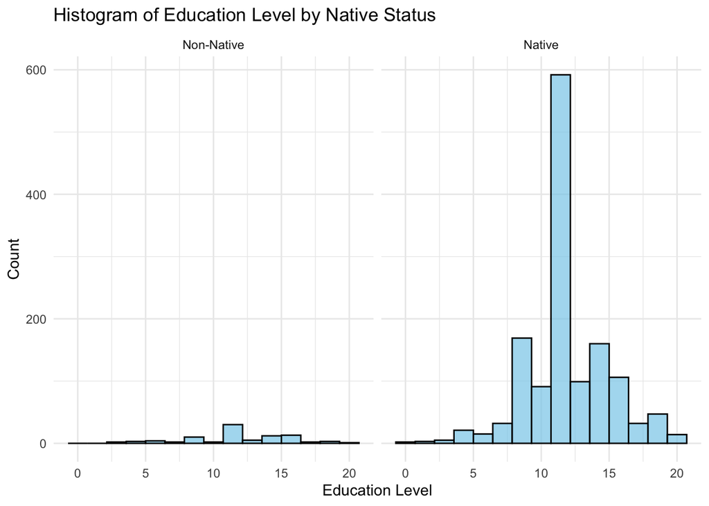

```r
# Faceted histogram of education level by native status
ggplot(data_clean, aes(x = educ)) +
  geom_histogram(bins = 15, fill = "skyblue", color = "black", alpha = 0.7) +
  facet_wrap(~nativeBorn, labeller = labeller(nativeBorn = c("no" = "Non-Native", "yes" = "Native"))) +
  labs(title = "Histogram of Education Level by Native Status",
       x = "Education Level",
       y = "Count") +
  theme_minimal()
```

**Answer: Given the small number of observations in the Non-Native category, I hypothesize that including the interaction term will have a minimal effect, as there is not enough data for the model to effectively learn from this group.**

Which model performs best?

```r
# Model without interaction
model_no_interaction <- lm(vocab ~ educ + nativeBorn, data = data_clean)

# Model with interaction
model_with_interaction <- lm(vocab ~ educ * nativeBorn, data = data_clean)

# Summaries to examine results
summary(model_no_interaction)
```

```
##
## Call:
## lm(formula = vocab ~ educ + nativeBorn, data = data_clean)
##
## Residuals:
##    Min     1Q Median     3Q    Max
## -7.162 -1.200  0.015  1.231  5.803
##
## Coefficients:
##               Estimate Std. Error t value Pr(>|t|)
## (Intercept)    0.62803    0.27651   2.271  0.02327 *
## educ           0.39222    0.01601  24.499  < 2e-16 ***
## nativeBornyes  0.65032    0.20551   3.164  0.00159 **
## ---
## Signif. codes:  0 '***' 0.001 '**' 0.01 '*' 0.05 '.' 0.1 ' ' 1
##
## Residual standard error: 1.879 on 1474 degrees of freedom
## Multiple R-squared:  0.2931, Adjusted R-squared:  0.2921
## F-statistic: 305.6 on 2 and 1474 DF,  p-value: < 2.2e-16
```

```r
summary(model_with_interaction)
```

```
##
## Call:
## lm(formula = vocab ~ educ * nativeBorn, data = data_clean)
##
## Residuals:
##     Min      1Q  Median      3Q     Max
## -7.1554 -1.2049  0.0149  1.2347  5.9857
##
## Coefficients:
##                    Estimate Std. Error t value Pr(>|t|)
## (Intercept)         0.35394    0.68780   0.515    0.607
## educ                0.41510    0.05496   7.553 7.45e-14 ***
## nativeBornyes       0.95000    0.71855   1.322    0.186
## educ:nativeBornyes -0.02501    0.05745  -0.435    0.663
## ---
## Signif. codes:  0 '***' 0.001 '**' 0.01 '*' 0.05 '.' 0.1 ' ' 1
##
## Residual standard error: 1.88 on 1473 degrees of freedom
## Multiple R-squared:  0.2932, Adjusted R-squared:  0.2917
## F-statistic: 203.7 on 3 and 1473 DF,  p-value: < 2.2e-16
```

```r
# Compare models using AIC
AIC(model_no_interaction, model_with_interaction)
```

```
##                        df      AIC
## model_no_interaction    4 6060.397
## model_with_interaction  5 6062.207
```

**Answer:** The interaction model (vocab ~ educ $\cdot$ nativeBorn) does not show a statistically significant interaction effect between education and native status. This indicates that the impact of education on vocabulary score does not significantly differ between native and non-native speakers. Additionally, the R-squared and adjusted R-squared values are nearly identical in both models, suggesting that adding the interaction term does not improve the model’s explanatory power.

Based on this, the model without the interaction term performs best as it provides a similar fit with fewer parameters, maintaining simplicity without losing explanatory power.

When creating plots, try to play around with the options of ggplot2 – add titles and axis labels, and consider using colours.